# Multiple Correspondence Analysis

Dataset hobbies

### 1. Study of the outliers

The analysis of the graphs does not detect any outlier.

### 2. Inertia distribution

The inertia of the first dimensions shows if there are strong relationships between variables and suggests the number of dimensions that should be studied.

The first two dimensions of analyse express **51.02%** of the total dataset inertia ; that means that 51.02% of the individuals (or variables) cloud total variability is explained by the plane. This percentage is relatively high and thus the first plane well represents the data variability. This value is strongly greater than the reference value that equals **10.38%**, the variability explained by this plane is thus highly significant (the reference value is the 0.95-quantile of the inertia percentages distribution obtained by simulating 101 data tables of equivalent size on the basis of a uniform distribution).

From these observations, it should be better to also interpret the dimensions greater or equal to the third one.

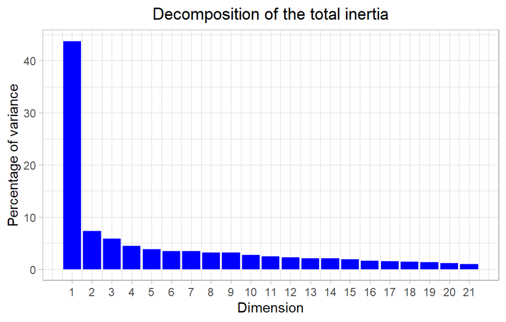

**Figure 2 - Decomposition of the total inertia**

An estimation of the right number of axis to interpret suggests to restrict the analysis to the description of the first 3 axis. These axis present an amount of inertia greater than those obtained by the 0.95-quantile of random distributions (56.82% against 15.48%). This observation suggests that only these axis are carrying a real information. As a consequence, the description will stand to these axis.

### 3. Description of the plane 1:2

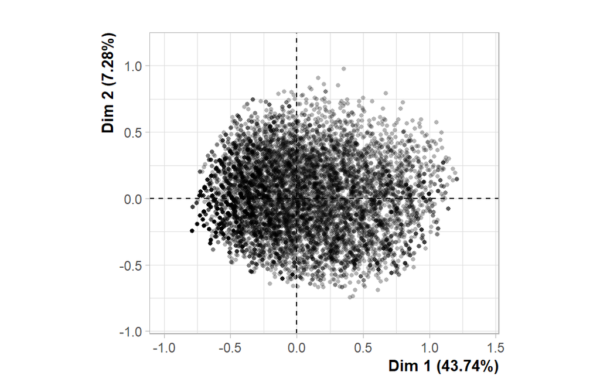

**Figure 3.1 - Individuals factor map (MCA)** *The labeled individuals are those with the higher contribution to the plane construction.*

The Wilks test p-value indicates which variable factors are the best separated on the plane (i.e. which one explain the best the distance between individuals).

```
##            Age Marital status     Profession            Sex
##   0.000000e+00  2.645312e-274  2.553530e-271   2.398947e-05
```

The best qualitative variable to illustrate the distance between individuals on this plane is : *Age*.

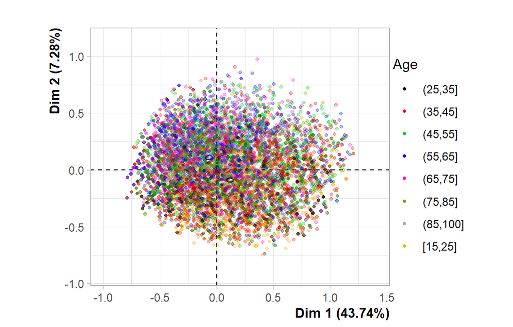

**Figure 3.2 - Individuals factor map (MCA)** *The labeled individuals are those with the higher contribution to the plane construction.* *The individuals are coloured after their category for the variable* Age.

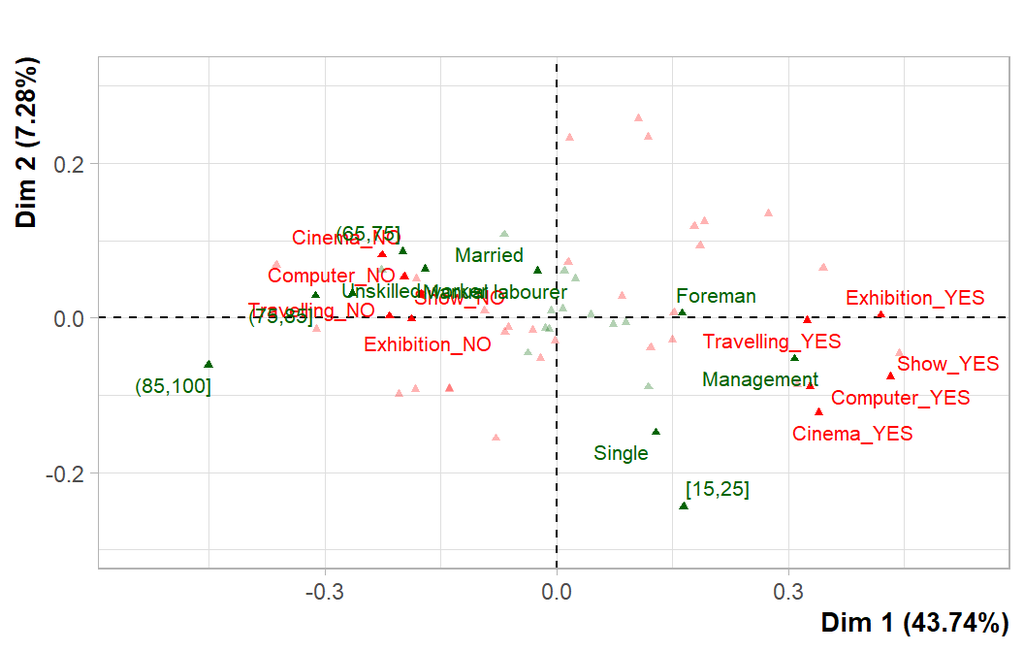

**Figure 3.3 - Variables factor map (MCA)** *The factors in red are considered as active whereas those in green are illustrative.* *The labeled variables are those the best shown on the plane.*

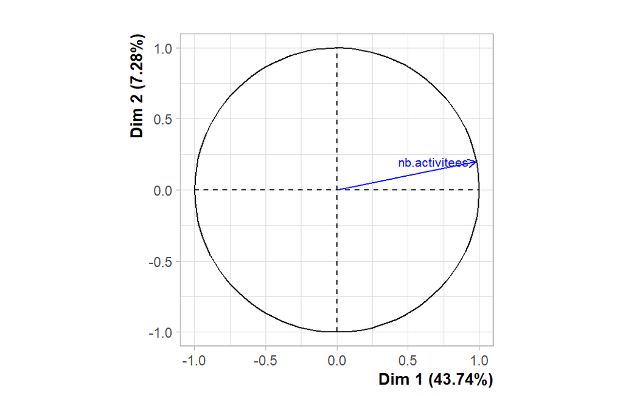

**Figure 3.4 - Quantitative factor map (MCA)** *The labeled variables are those the best shown on the plane.*

The **dimension 1** opposes individuals characterized by a strongly positive coordinate on the axis (to the right of the graph) to individuals characterized by a strongly negative coordinate on the axis (to the left of the graph).

The group 1 (characterized by a positive coordinate on the axis) is sharing :

- high frequency for factors like *Sport=Sport_YES*, *Computer=Computer_YES*, *Show=Show_YES*, *Cinema=Cinema_YES*, *Listening.music=Listening music_YES*, *Travelling=Travelling_YES*, *Exhibition=Exhibition_YES*, *Reading=Reading_YES*, *Playing.music=Playing music_YES* and *Marital.status=Single* (factors are sorted from the most common).
- low frequency for factors like *Cinema=Cinema_NO*, *Show=Show_NO*, *Computer=Computer_NO*, *Sport=Sport_NO*, *Listening.music=Listening music_NO*, *Travelling=Travelling_NO*, *Exhibition=Exhibition_NO*, *Reading=Reading_NO*, *Playing.music=Playing music_NO* and *Age=(65,75]* (factors are sorted from the rarest).

The group 2 (characterized by a positive coordinate on the axis) is sharing :

- high frequency for factors like *Gardening=Gardening_YES*, *Mechanic=Mechanic_YES*, *Cooking=Cooking_YES*, *Walking=Walking_YES*, *Exhibition=Exhibition_YES*, *Travelling=Travelling_YES*, *Knitting=Knitting_YES*, *Reading=Reading_YES*, *Listening.music=Listening music_YES* and *Volunteering=Volunteering_YES* (factors are sorted from the most common).
- low frequency for factors like *Gardening=Gardening_NO*, *Mechanic=Mechanic_NO*, *Cooking=Cooking_NO*, *Walking=Walking_NO*, *Exhibition=Exhibition_NO*, *Travelling=Travelling_NO*, *Knitting=Knitting_NO*, *Reading=Reading_NO*, *Listening.music=Listening music_NO* and *Volunteering=Volunteering_NO* (factors are sorted from the rarest).

The group 3 (characterized by a negative coordinate on the axis) is sharing :

- high frequency for factors like *Travelling=Travelling_NO*, *Computer=Computer_NO*, *Exhibition=Exhibition_NO*, *Show=Show_NO*, *Cinema=Cinema_NO*, *Sport=Sport_NO*, *Reading=Reading_NO*, *Walking=Walking_NO*, *Listening.music=Listening music_NO* and *Cooking=Cooking_NO* (factors are sorted from the most common).
- low frequency for factors like *Cinema=Cinema_YES*, *Show=Show_YES*, *Exhibition=Exhibition_YES*, *Computer=Computer_YES*, *Travelling=Travelling_YES*, *Sport=Sport_YES*, *Reading=Reading_YES*, *Walking=Walking_YES*, *Listening.music=Listening music_YES* and *Cooking=Cooking_YES* (factors are sorted from the rarest).

The group 4 (characterized by a negative coordinate on the axis) is sharing :

- high frequency for factors like *Gardening=Gardening_YES*, *Cinema=Cinema_NO*, *Computer=Computer_NO*, *Sport=Sport_NO*, *Show=Show_NO*, *Knitting=Knitting_YES*, *Exhibition=Exhibition_NO*, *Listening.music=Listening music_NO*, *Playing.music=Playing music_NO* and *Travelling=Travelling_NO* (factors are sorted from the most common).
- low frequency for factors like *Gardening=Gardening_NO*, *Cinema=Cinema_YES*, *Computer=Computer_YES*, *Sport=Sport_YES*, *Show=Show_YES*, *Knitting=Knitting_NO*, *Exhibition=Exhibition_YES*, *Listening.music=Listening music_YES*, *Playing.music=Playing music_YES* and *Travelling=Travelling_YES* (factors are sorted from the rarest).

The **dimension 2** opposes individuals characterized by a strongly positive coordinate on the axis (to the top of the graph) to individuals characterized by a strongly negative coordinate on the axis (to the bottom of the graph).

The group 1 (characterized by a positive coordinate on the axis) is sharing :

- high frequency for factors like *Gardening=Gardening_YES*, *Cinema=Cinema_NO*, *Computer=Computer_NO*, *Sport=Sport_NO*, *Show=Show_NO*, *Knitting=Knitting_YES*, *Exhibition=Exhibition_NO*, *Listening.music=Listening music_NO*, *Playing.music=Playing music_NO* and *Travelling=Travelling_NO* (factors are sorted from the most common).
- low frequency for factors like *Gardening=Gardening_NO*, *Cinema=Cinema_YES*, *Computer=Computer_YES*, *Sport=Sport_YES*, *Show=Show_YES*, *Knitting=Knitting_NO*, *Exhibition=Exhibition_YES*, *Listening.music=Listening music_YES*, *Playing.music=Playing music_YES* and *Travelling=Travelling_YES* (factors are sorted from the rarest).

The group 2 (characterized by a positive coordinate on the axis) is sharing :

- high frequency for factors like *Gardening=Gardening_YES*, *Mechanic=Mechanic_YES*, *Cooking=Cooking_YES*, *Walking=Walking_YES*, *Exhibition=Exhibition_YES*, *Travelling=Travelling_YES*, *Knitting=Knitting_YES*, *Reading=Reading_YES*, *Listening.music=Listening music_YES* and *Volunteering=Volunteering_YES* (factors are sorted from the most common).
- low frequency for factors like *Gardening=Gardening_NO*, *Mechanic=Mechanic_NO*, *Cooking=Cooking_NO*, *Walking=Walking_NO*, *Exhibition=Exhibition_NO*, *Travelling=Travelling_NO*, *Knitting=Knitting_NO*, *Reading=Reading_NO*, *Listening.music=Listening music_NO* and *Volunteering=Volunteering_NO* (factors are sorted from the rarest).

The group 3 (characterized by a negative coordinate on the axis) is sharing :

- high frequency for factors like *Travelling=Travelling_NO*, *Computer=Computer_NO*, *Exhibition=Exhibition_NO*, *Show=Show_NO*, *Cinema=Cinema_NO*, *Sport=Sport_NO*, *Reading=Reading_NO*, *Walking=Walking_NO*, *Listening.music=Listening music_NO* and *Cooking=Cooking_NO* (factors are sorted from the most common).
- low frequency for factors like *Cinema=Cinema_YES*, *Show=Show_YES*, *Exhibition=Exhibition_YES*, *Computer=Computer_YES*, *Travelling=Travelling_YES*, *Sport=Sport_YES*, *Reading=Reading_YES*, *Walking=Walking_YES*, *Listening.music=Listening music_YES* and *Cooking=Cooking_YES* (factors are sorted from the rarest).

The group 4 (characterized by a negative coordinate on the axis) is sharing :

- high frequency for factors like *Sport=Sport_YES*, *Computer=Computer_YES*, *Show=Show_YES*, *Cinema=Cinema_YES*, *Listening.music=Listening music_YES*, *Travelling=Travelling_YES*, *Exhibition=Exhibition_YES*, *Reading=Reading_YES*, *Playing.music=Playing music_YES* and *Marital.status=Single* (factors are sorted from the most common).
- low frequency for factors like *Cinema=Cinema_NO*, *Show=Show_NO*, *Computer=Computer_NO*, *Sport=Sport_NO*, *Listening.music=Listening music_NO*, *Travelling=Travelling_NO*, *Exhibition=Exhibition_NO*, *Reading=Reading_NO*, *Playing.music=Playing music_NO* and *Age=(65,75]* (factors are sorted from the rarest).

### 4. Description of the dimension 3

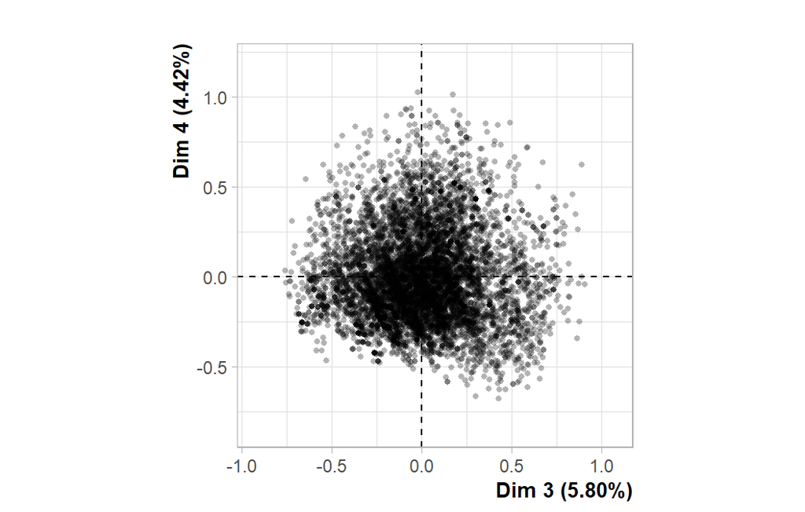

**Figure 4.1 - Individuals factor map (MCA)** *The labeled individuals are those with the higher contribution to the plane construction.*

The Wilks test p-value indicates which variable factors are the best separated on the plane (i.e. which one explain the best the distance between individuals).

```
##            Sex            Age     Profession Marital status
##   0.000000e+00  1.303727e-156  3.484020e-139   5.682643e-83
```

The best qualitative variable to illustrate the distance between individuals on this plane is : *Sex*.

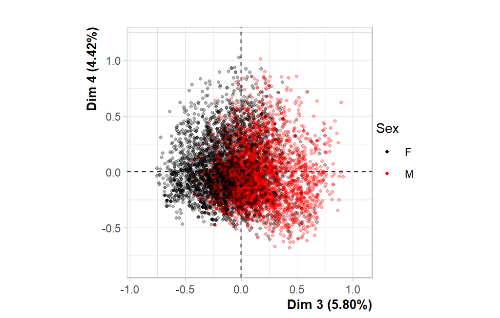

**Figure 4.2 - Individuals factor map (MCA)** *The labeled individuals are those with the higher contribution to the plane construction.* *The individuals are coloured after their category for the variable* Sex.

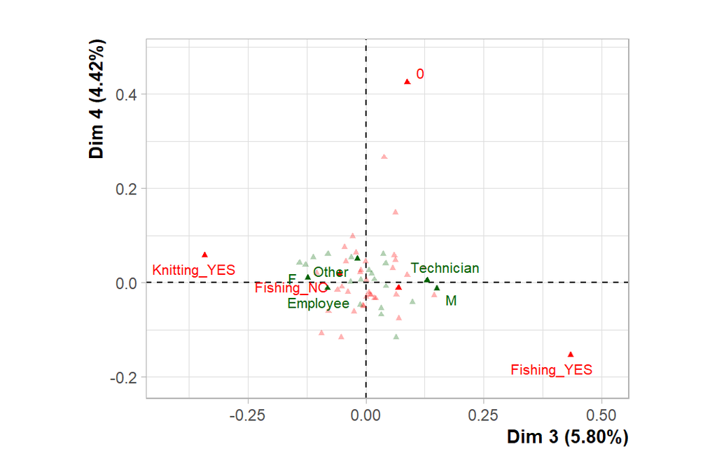

**Figure 4.3 - Variables factor map (MCA)** *The factors in red are considered as active whereas those in green are illustrative.* *The labeled variables are those the best shown on the plane.*

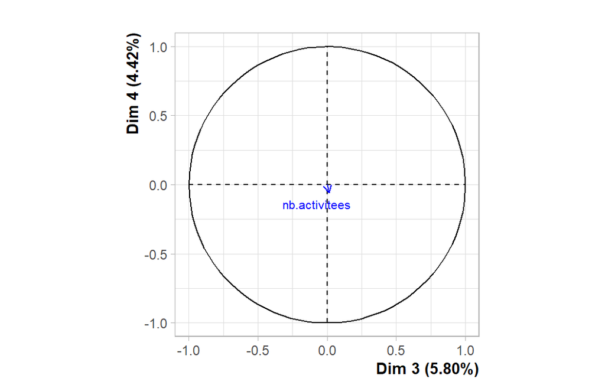

**Figure 4.4 - Quantitative factor map (MCA)** *The labeled variables are those the best shown on the plane.*

The **dimension 3** opposes individuals characterized by a strongly positive coordinate on the axis (to the right of the graph) to individuals characterized by a strongly negative coordinate on the axis (to the left of the graph).

The group 1 (characterized by a positive coordinate on the axis) is sharing :

- high frequency for factors like *Fishing=Fishing_YES*, *Mechanic=Mechanic_YES*, *Sex=M*, *Knitting=Knitting_NO*, *Computer=Computer_YES*, *TV=2*, *Sport=Sport_YES*, *Reading=Reading_NO*, *Gardening=Gardening_YES* and *Profession=Manual labourer* (factors are sorted from the most common).
- low frequency for factors like *Fishing=Fishing_NO*, *Mechanic=Mechanic_NO*, *Sex=F*, *Knitting=Knitting_YES*, *Computer=Computer_NO*, *TV=0*, *Sport=Sport_NO*, *Reading=Reading_YES*, *Marital.status=Widower* and *Gardening=Gardening_NO* (factors are sorted from the rarest).

The group 2 (characterized by a negative coordinate on the axis) is sharing :

- high frequency for factors like *Sex=F*, *Fishing=Fishing_NO*, *Mechanic=Mechanic_NO*, *Knitting=Knitting_YES*, *TV=4*, *Cooking=Cooking_YES*, *Sport=Sport_NO*, *Reading=Reading_YES*, *Listening.music=Listening music_YES* and *Volunteering=Volunteering_NO* (factors are sorted from the most common).
- low frequency for factors like *Sex=M*, *TV=0*, *Fishing=Fishing_YES*, *Mechanic=Mechanic_YES*, *Knitting=Knitting_NO*, *Cooking=Cooking_NO*, *Sport=Sport_YES*, *Reading=Reading_NO*, *Listening.music=Listening music_NO* and *Volunteering=Volunteering_YES* (factors are sorted from the rarest).

### 5. Classification

The dataset is too large to perform the classification.